# Reproducible Research: Peer Assessment 1

Hic

15/06/2020

## Loading and preprocessing the data

```r
  data <- read.csv("activity.csv")
  data$date = as.Date(data$date)
  head(data)
```

```
##   steps       date interval
## 1    NA 2012-10-01        0
## 2    NA 2012-10-01        5
## 3    NA 2012-10-01       10
## 4    NA 2012-10-01       15
## 5    NA 2012-10-01       20
## 6    NA 2012-10-01       25
```

## calculate the mean total number of steps taken per day

we group the data per day

display the data as a table :

```r
  data_mean
```

```
## # A tibble: 61 x 4
##    date       nbr_steps mean_steps median_steps
##    <date>         <int>      <dbl>        <dbl>
##  1 2012-10-01         0    NaN               NA
##  2 2012-10-02       126      0.438            0
##  3 2012-10-03     11352     39.4              0
##  4 2012-10-04     12116     42.1              0
##  5 2012-10-05     13294     46.2              0
##  6 2012-10-06     15420     53.5              0
##  7 2012-10-07     11015     38.2              0
##  8 2012-10-08         0    NaN               NA
##  9 2012-10-09     12811     44.5              0
## 10 2012-10-10      9900     34.4              0
## # ... with 51 more rows
```

histogrrame of the number of steps per day

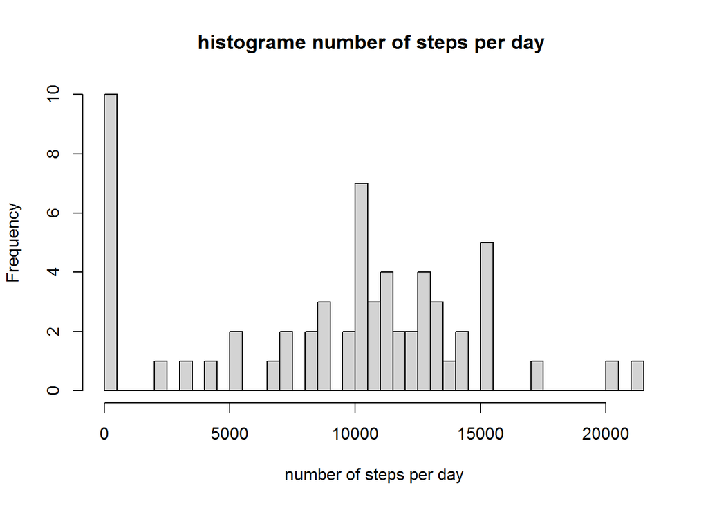

```r
    hist(data_mean$nbr_steps  , xlab = "number of steps per day" , main = "histograme number of steps per day " , breaks = 61  )
```

display the mean variations in a bar plot :

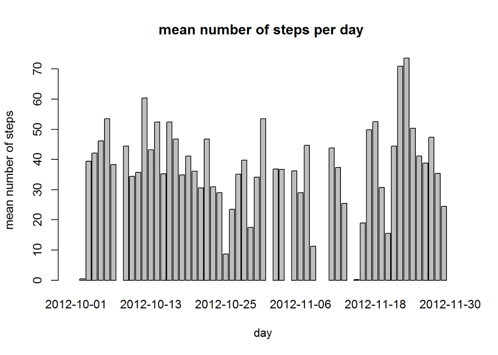

```r
    barplot(data_mean$mean_steps , names.arg = data_mean$date , xlab = "day" , ylab = "mean number of steps" , main = "mean number of steps per day "  )
```

display the median variations in a bar plot

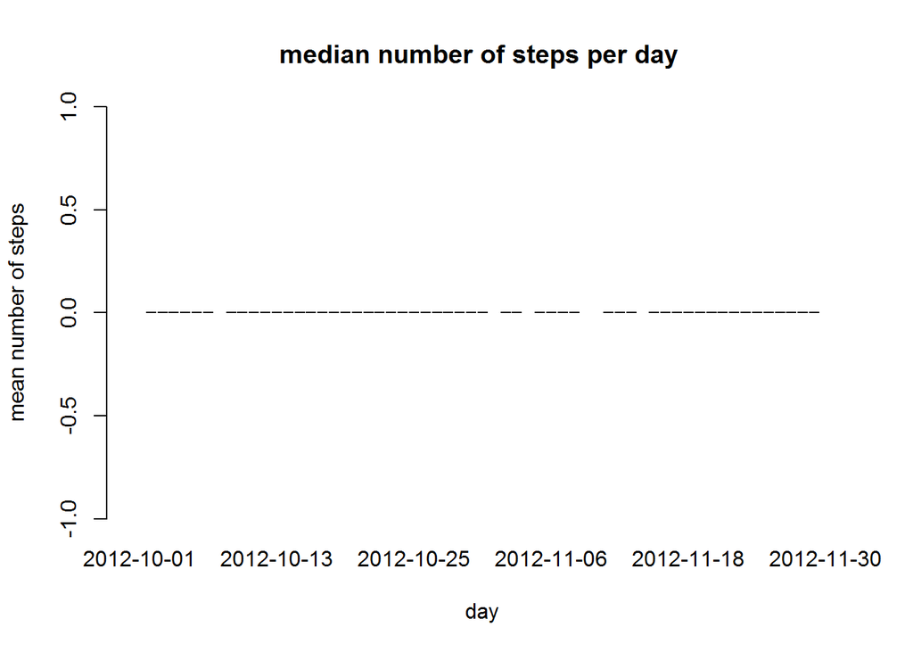

```r
    barplot(data_mean$median_steps , names.arg = data_mean$date , xlab = "day" , ylab = "mean number of steps" , main = "median number of steps per day "  )
```

report the mean :

```r
 mean(data_mean$nbr_steps , na.rm = TRUE)
```

```
## [1] 9354.23
```

report the median :

```r
 median(data_mean$nbr_steps , na.rm = TRUE)
```

```
## [1] 10395
```

## the average daily activity pattern :

first thing we group the data by the 5-minutes interval

```r
 data_5m_grp <- group_by(data , interval)
 data_5m_mean <- summarize(data_5m_grp , mean_steps_per_interv = mean(steps , na.rm = TRUE))
 data_5m_mean
```

```
## # A tibble: 288 x 2
##    interval mean_steps_per_interv
##       <int>                 <dbl>
##  1        0                1.72
##  2        5                0.340
##  3       10                0.132
##  4       15                0.151
##  5       20                0.0755
##  6       25                2.09
##  7       30                0.528
##  8       35                0.868
##  9       40                0
## 10       45                1.47
## # ... with 278 more rows
```

plot the time serie of the 5-minute interval (x-axis) and the average number of steps taken, averaged across all days (y-axis) we devide the interval number by 5 to better visualize the plot

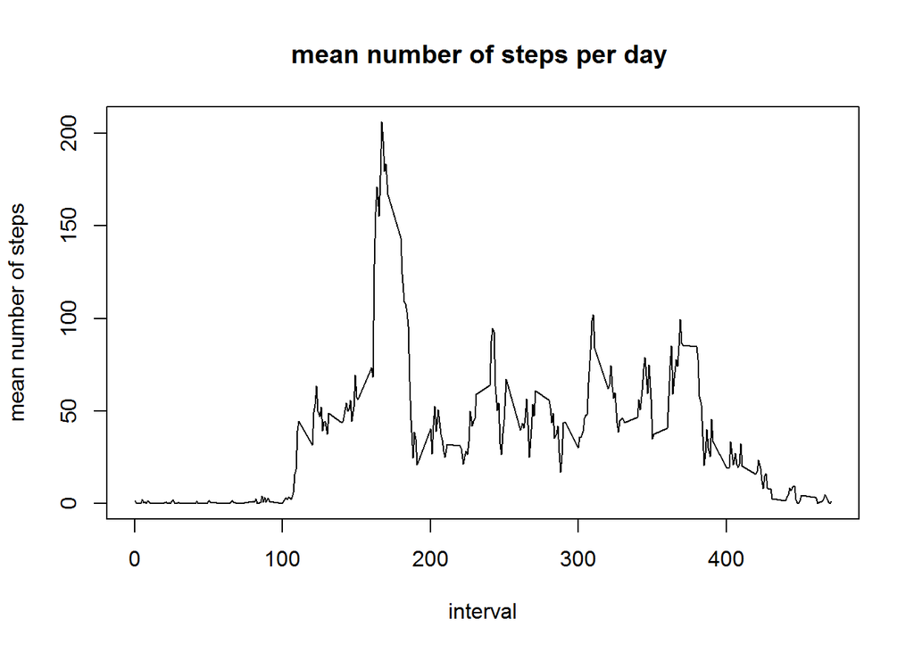

```r
  plot(x = data_5m_mean$interval / 5 , y = data_5m_mean$mean_steps_per_interv , xlab = "interval" , ylab = "mean number of steps" , main = "mean number of steps per day " , type = "l" )
```

```r
  subset(data_5m_mean, mean_steps_per_interv == max(mean_steps_per_interv , na.rm = TRUE))
```

```
## # A tibble: 1 x 2
##   interval mean_steps_per_interv
##      <int>                 <dbl>
## 1      835                  206.
```

the maximum value is at 8h35

## imputing missing values

```r
  nrow(subset(data , is.na(steps)))
```

```
## [1] 2304
```

the number of missing values in the dataset is 2304

now lets impute the missing values using the “pmm” method implemented by the mice library

```r
    library(mice)
    imputed_Data <- mice(data,m=5,maxit=3,meth='pmm',seed=500)
    imputed_Data <- complete(imputed_Data)
    nrow(subset(imputed_Data , is.na(steps)))
```

```
## [1] 0
```

as you can see the number of missing values now is zero

we group the imputed data by day

```r
  imputed_grp <- group_by(imputed_Data , date)
  imputed_day_grp <- summarise(imputed_grp , sum_steps = sum(steps) , mean_steps = mean(steps) , median_steps = median(steps) )
```

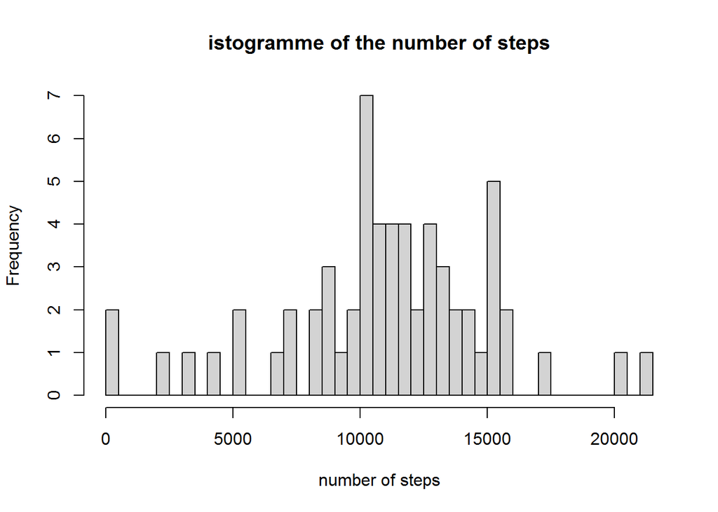

```r
  hist(imputed_day_grp$sum_steps , breaks = 61 , main = "istogramme of the number of steps" , xlab = "number of steps")
```

report the mean and median total number of steps taken per day

```r
  mean(imputed_day_grp$sum_steps)
```

```
## [1] 11046.64
```

```r
  median(imputed_day_grp$sum_steps)
```

```
## [1] 11162
```

using the pmm method to impute the missing data has changed the vaue of the mean and median

## the differences in activity patterns between weekdays and weekends

first we create a factor variable indicating if the day is a weekend or a weekday then we group the number of steps per interval and we calcuate the mean

```
##   steps       date interval    week
## 1    NA 2012-10-01        0 weekday
## 2    NA 2012-10-01        5 weekday
## 3    NA 2012-10-01       10 weekday
## 4    NA 2012-10-01       15 weekday
## 5    NA 2012-10-01       20 weekday
## 6    NA 2012-10-01       25 weekday
```

after this we plot the results

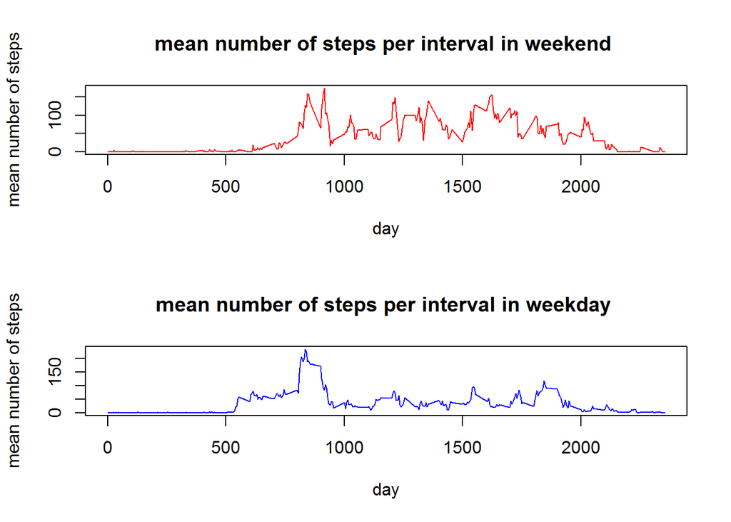

```r
par(mfrow = c(2, 1))
  plot(y = mean_data_weekend$mean_steps , x =  mean_data_weekend$interval , xlab = "day" , ylab = "mean number of steps" , main = "mean number of steps per interval in weekend " , type = "l" , col = "red"  )
  plot(y = mean_data_weekday$mean_steps , x = mean_data_weekend$interval , xlab = "day" , ylab = "mean number of steps" , main = "mean number of steps per interval in weekday " ,type = "l" , col ="blue" )
```

we notice that there’s a small difference in activity pattern, in the weekend there’s more steps that in the weekday in the period between 10 to 15, maybe because in the weekday the individual is at work so he’s not walking between 10 and 15